# Jiwon Baik

### 07/09/2021

# COVID-19 Pandemic

```r
covid = read_csv('https://raw.githubusercontent.com/nytimes/covid-19-data/master/us-counties.csv')

pop = readxl:::read_excel("data/populationEstimates.xls", skip = 2) %>%
  select(pop2019 = POP_ESTIMATE_2019, State = State, fips = FIPStxt)

pop_ca2019 = pop %>%
  filter(State == "CA") %>%
  slice_max(pop2019, n = 1)

cases = covid %>%
  filter(state %in% c("California")) %>%
  group_by(county) %>%
  mutate(newCases = cases - lag(cases)) %>%
  ungroup() %>%
  filter(date == max(date))


most_cases = cases %>%
  slice_max(cases, n = 5) %>%
  select(county, cases)

knitr::kable(most_cases,
             caption = "Most Cases California Counties",
             col.names = c("County", "Cases"))
```

Most Cases California Counties

| County | Cases |
| --- | --- |
| Los Angeles | 2132227 |
| San Diego | 587767 |
| Riverside | 478326 |
| San Bernardino | 463256 |
| Orange | 451612 |

```r
most_new_cases = cases %>%
  slice_max(newCases, n = 5) %>%
  select(county, newCases)

knitr::kable(most_new_cases,
             caption = "Most New Cases California Counties",
             col.names = c("County", "New Cases"))
```

Most New Cases California Counties

| County | New Cases |
| --- | --- |
| Los Angeles | 44942 |
| San Diego | 24639 |
| Orange | 11847 |
| Sacramento | 7713 |
| San Bernardino | 6901 |

```r
pop_data1 = right_join(pop, cases, by = "fips") %>%
  mutate(cases_percapita = (cases / pop2019) * 100000,
         newCases_percapita = (newCases / pop2019) * 100000)

most_cases_percapita = pop_data1 %>%
  slice_max(cases_percapita, n = 5) %>%
  select(county, cases_percapita)

knitr::kable(most_cases_percapita,
             caption = "Most Cumulative Cases Per Capita",
             col.names = c("County", "Cases"))
```

Most Cumulative Cases Per Capita

| County | Cases |
| --- | --- |
| Lassen | 27916.79 |
| Imperial | 26274.32 |
| Kings | 25650.58 |
| San Bernardino | 21249.45 |
| Los Angeles | 21239.21 |

```r
most_new_cases_percapita = pop_data1 %>%
  slice_max(newCases_percapita, n = 5) %>%
  select(county, newCases_percapita)

knitr::kable(most_new_cases_percapita,
             caption = "Most New Cases Per Capita",
             col.names = c("County", "New Cases"))
```

Most New Cases Per Capita

| County | New Cases |
| --- | --- |
| Lassen | 830.7984 |
| Imperial | 826.6424 |
| San Diego | 738.0636 |
| Mono | 650.7893 |
| Monterey | 636.7769 |

```r
pop_data2 = right_join(pop, covid, by = "fips") %>%
  filter(date >= max(date) - 13, state == "California")

state_daysdata = pop_data2 %>%
 group_by(state, date) %>%
  summarise(cases = sum(cases)) %>%
  mutate(newCases = cases - lag(cases),
         newCases_percapita = (newCases / 39512223) * 100000) %>%
  ungroup()

safe_county = pop_data2 %>%
  group_by(county, pop2019) %>%
  summarize(max_cases = max(cases), min_cases = min(cases)) %>%
  mutate(newCases = max_cases - min_cases,
         newCases_percapita = (newCases / pop2019) * 100000) %>%
  filter(newCases_percapita <= 100) %>%
  ungroup()

Numofcounty = length(safe_county$county)
Numofnewcases = format(max(state_daysdata$cases) - min(state_daysdata$cases))
Numofcases = format(max(state_daysdata$cases))
```

As the data showing on above, in California’s last **14** days, the total number of cases is **6716565**, the total number of new cases is **1200952**, and the total number of safe county is **0**.

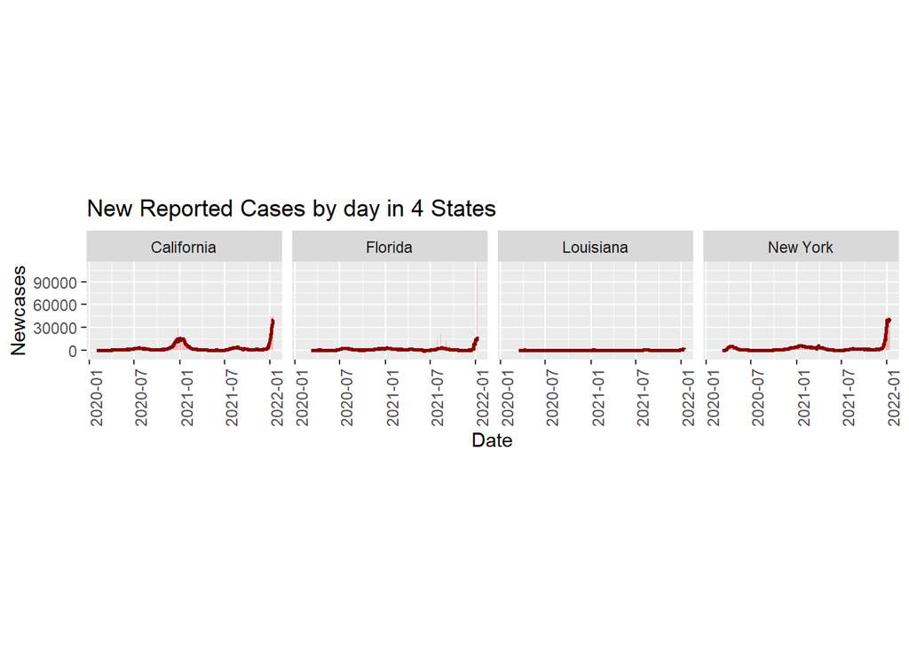

```r
covid %>%
  filter(state %in% c("New York", "California", "Louisiana", "Florida")) %>%
  group_by(state, date) %>%
  summarise(cases = max(cases))%>%
  mutate(newCases = cases - lag(cases), roll7 = rollmean(newCases, 7, fill = NA, align = "right")) %>%
  ungroup() %>%
  ggplot(aes(x = date)) +
  geom_col(aes(y = newCases), col = NA, fill = "#F5B8B5") +
  geom_line(aes(y = roll7), col = "darkred", size = 1) +
  theme_gray() +
  labs(title = "New Reported Cases by day in 4 States", x = "Date", y = "Newcases") +
  theme(aspect.ratio = .5) +
  facet_grid(~state, scales = "free_y") +
  theme(axis.text.x = element_text(angle = 90))
```

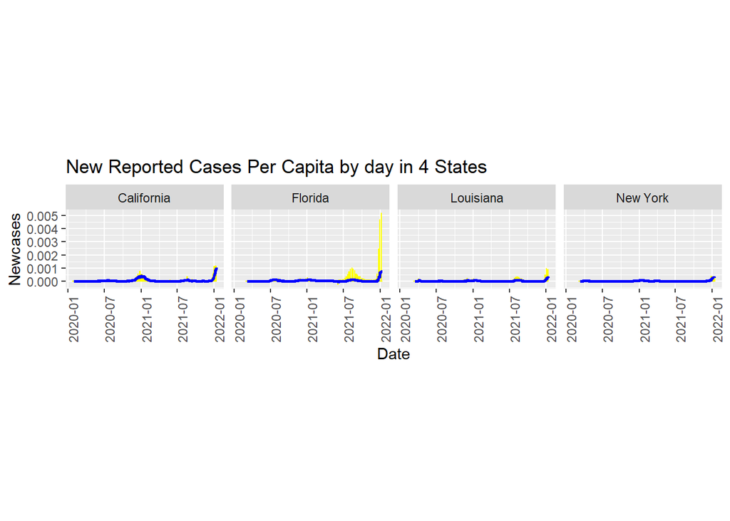

```r
COVID1 = covid %>%
  filter(state %in% c("New York", "California", "Louisiana", "Florida")) %>%
  right_join(pop, by = "fips")


state_pop = pop %>%
  filter(State %in% c("NY", "CA","LA", "FL")) %>%
  group_by(State) %>%
  slice_max(pop2019, n = 1) %>%
  right_join(COVID1, by = "State") %>%
  select(pop = pop2019.x, date, state, cases, deaths) %>%
  ungroup() %>%
  filter(state %in% c("New York", "California", "Louisiana", "Florida")) %>%
  group_by(pop, state,date) %>%
  summarise(cases = max(cases)) %>%
  mutate(newCases1 = cases - lag(cases), newCases_Percapita = newCases1 / pop, Roll7 = rollmean(newCases_Percapita, 7, fill = NA, align = "right")) %>%
  ungroup()

ggplot(state_pop, aes(x = date)) +
  geom_col(aes(y = newCases_Percapita), col = "yellow", fill = "#F5B8B5") +
  geom_line(aes(y = Roll7), col = "blue", size = 1) +
  theme_gray() +
  labs(title = "New Reported Cases Per Capita by day in 4 States ", x = "Date", y = "Newcases") +
  theme(aspect.ratio = .5) +
  facet_grid(~state, scales = "free_y") +
  theme(axis.text.x = element_text(angle = 90))
```

With the data of population, the graph is more sensitive to the local condition of the pandemic. Because some states’ population is small such as Louisiana, the basic infected number is too small to evaluate and we cannot analyze the changes from the cases itself. Cases per capita solves the problem when we try to monitor local pandemic changes. In addition, cases per capita also can help us observe the control of the infection locally. But sometimes it is biased. The total number of the cases matters when we try to define the disease’s pandemic condition in specific area. Analysis of both of them is better way to monitor the pandemic.

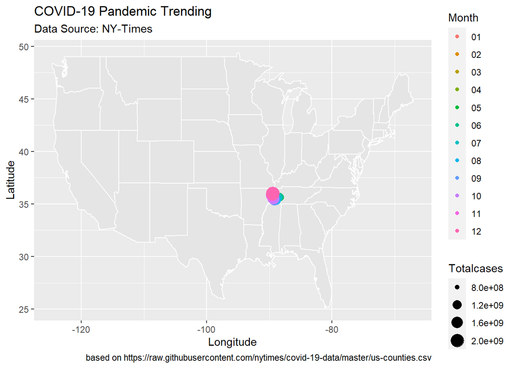

```r
local = na.omit(readr::read_csv("data/county-centroids.csv"))  %>%
  select(fips, county = name, state = state_name, LON, LAT)

local_data1 = covid %>%
  group_by(date, county, fips) %>%
  ungroup() %>%
  left_join(local, by = "fips") %>%
  select(date, county = county.x, fips, cases, LAT, LON) %>%
  mutate(Month = format(date, "%m")) %>%
  group_by(Month) %>%
  summarise(X = sum(LAT * cases, na.rm = TRUE) / sum(cases, na.rm = TRUE),
            Y = sum(LON * cases, na.rm = TRUE) / sum(cases, na.rm = TRUE),
            Totalcases = sum(cases, na.rm =TRUE ))





ggplot(local_data1, aes(x = Y, y = X)) +
  borders("state", fill = "gray90", colour = "white") +
  geom_point(aes(color = Month, size = Totalcases)) +
  labs(title = "COVID-19 Pandemic Trending ",
       x = "Longitude",
       y = "Latitude",
       caption = "based on https://raw.githubusercontent.com/nytimes/covid-19-data/master/us-counties.csv",
       subtitle = 'Data Source: NY-Times',
       color = "Month") +
  theme_gray()
```

From the data trending, total number of cases continually increases from last summer in 2020. The weighted mean center of the is near the southeast of the States and slightly moved to west last winter and back to southeast this summer because the huge infection number in southeast states such as Florida last summer and increase of cases in California last winter. With the injection of the vaccine, rate of increase started to decrease in spring 2021.